# Continuous cough monitoring: a novel digital biomarker for tuberculosis diagnosis and treatment response monitoring

```r
df_long_comp<-read.csv("2022_10_19_coughdata.csv")
```

# Cough Frequency Comparison

```r
tab2<-matrix(NA,nrow=4, ncol=2)
rownames(tab2)<-c("Microbiologically confirmed TB", "Clinical TB", "Other respiratory diseases", "Overall")
colnames(tab2)<-c("Day 1", "Day 14")

med_iqr<-function(vec){
  output<-paste0(median(vec, na.rm=T)," (",
                 quantile(vec,.25 ,na.rm=T), ", ",
                 quantile(vec,.75 ,na.rm=T), ")" )
  return(output)
}
tab2[1,1]<- med_iqr(df_long_comp$median_cph[df_long_comp$long_day==1&df_long_comp$dx=="Microbiologic TB"])
tab2[1,2]<- med_iqr(df_long_comp$median_cph[df_long_comp$long_day==14&df_long_comp$dx=="Microbiologic TB"])

tab2[2,1]<- med_iqr(df_long_comp$median_cph[df_long_comp$long_day==1&df_long_comp$dx=="Clinical TB"])
tab2[2,2]<- med_iqr(df_long_comp$median_cph[df_long_comp$long_day==14&df_long_comp$dx=="Clinical TB"])

tab2[3,1]<- med_iqr(df_long_comp$median_cph[df_long_comp$long_day==1&df_long_comp$dx=="TB Negative"])
tab2[3,2]<- med_iqr(df_long_comp$median_cph[df_long_comp$long_day==14&df_long_comp$dx=="TB Negative"])

tab2[4,1]<- med_iqr(df_long_comp$median_cph[df_long_comp$long_day==1])
tab2[4,2]<- med_iqr(df_long_comp$median_cph[df_long_comp$long_day==14])


tab2 %>%
  kbl(caption="Comparison of medCPH (Q1, Q3) at Day 1 and Day 14. ") %>%
  kable_minimal()
```

Comparison of medCPH (Q1, Q3) at Day 1 and Day 14.

|  | Day 1 | Day 14 |
| --- | --- | --- |
| Microbiologically confirmed TB | 8 (3.5, 19) | 4 (2, 8) |
| Clinical TB | 5 (2, 9) | 3 (2, 4.875) |
| Other respiratory diseases | 5 (3, 8) | 3 (2, 6) |
| Overall | 5 (3, 9) | 3.5 (2, 6) |

## Statistical tests of difference in cough frequency at Day 1 and Day 14

```r
#Strong right skew of data, will have to do non-parametric testing
#hist(df_long$median_cph[df_long$long_day==1&df_long$dx=="Microbiologic TB"])
#hist(df_long$median_cph[df_long$long_day==14])

day1_overall<-subset(df_long_comp, long_day==1 )
day14_overall<-subset(df_long_comp, long_day==14)

day1_micro<-subset(df_long_comp, long_day==1 & dx=="Microbiologic TB")
day14_micro<-subset(df_long_comp, long_day==14 & dx=="Microbiologic TB")

day1_neg<-subset(df_long_comp, long_day==1 & dx=="TB Negative")
day14_neg<-subset(df_long_comp, long_day==14 & dx=="TB Negative")

day1_clin<-subset(df_long_comp, long_day==1 & dx=="Clinical TB")
day14_clin<-subset(df_long_comp, long_day==14 & dx=="Clinical TB")


day1_test<-wilcox.test(day1_micro$median_cph, day1_neg$median_cph, alternative = "two.sided", paired=F)
day14_test<-wilcox.test(day14_micro$median_cph, day14_neg$median_cph, alternative = "two.sided", paired=F)

day1_clintest<-wilcox.test(day1_clin$median_cph, day1_neg$median_cph, alternative = "two.sided", paired=F)
day14_clintest<-wilcox.test(day14_clin$median_cph, day14_neg$median_cph, alternative = "two.sided", paired=F)
```

Median coughs per hour demonstrate strong right skews at both Day 1 and Day 14. To compare the medians I am using a two sample Wilcoxon test.

The median Day 1 median cough per hour for Microbiological TB is 8 (IQR: 3.5 - 19); for Negative patients it is 5 (IQR: 3 - 8). This difference is significant (p-value=0). The Day 1 median cough per hour for Clinical TB patients is 5 (IQR: 2 - 9) and this is not significantly different from the negative patient median (p-value=0.76).

The median Day 14 median cough per hour for Microbiological TB is 4 (IQR: 2 - 8); for Negative patients it is 3 (IQR: 2 - 6). This difference is not significant (p-value=0.38). The Day 14 median cough per hour for Clinical TB patients is 3 (IQR: 2 - 4.875) and this is not significantly different from the negative patient median (p-value=0.24).

### Overall TB comparison Day 1 to Day 14

```r
overall_comparison<-wilcox.test(day1_overall$median_cph, day14_overall$median_cph, alternative = "two.sided", paired=T)
```

The cough frequency among all patients decreased significantly between Day 1 and Day 14 (p-value=0)

### Microbiologic TB comparison Day 1 to Day 14

```r
micro_comparison<-wilcox.test(day1_micro$median_cph, day14_micro$median_cph, alternative = "two.sided", paired=T)
```

The cough frequency among Microbiological TB patients decreased significantly between Day 1 and Day 14 (p-value=0)

### Clinical TB comparison Day 1 to Day 14

```r
clin_comparison<-wilcox.test(day1_clin$median_cph, day14_clin$median_cph, alternative = "two.sided", paired=T)
```

The cough frequency among Clinical TB patients decreased significantly between Day 1 and Day 14 (p-value=0)

### ORD comparison Day 1 to Day 14

```r
ord_comparison<-wilcox.test(day1_neg$median_cph, day14_neg$median_cph, alternative = "two.sided", paired=T)
```

The cough frequency among ORD patients decreased significantly between Day 1 and Day 14 (p-value=0)

# Longitudinal Cough Trajectories by Diagnostic Status

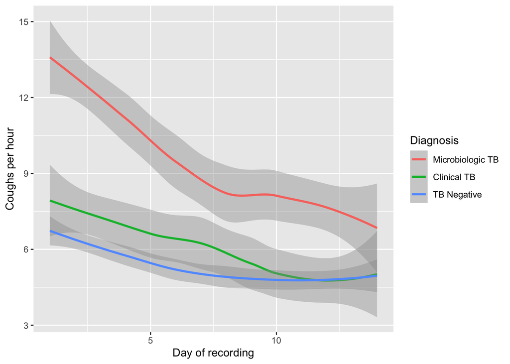

```r
df_long_comp$dx_lab<-factor(df_long_comp$dx, levels=c("Microbiologic TB","Clinical TB", "TB Negative"))


ggplot(df_long_comp, aes(x = long_day, y = median_cph, color=dx_lab)) +
  geom_smooth(method = "loess") +xlab("Day of recording") + ylab("Coughs per hour") +labs(color="Diagnosis")
```